# Lesson 2: Plotting

Matt Clark

11/25/2019

# Introduction

Plotting your data is the most effective way of communicating complex results and getting others to understand why you reserch matters! Plotting your data is also a good first stop to make sure everything looks okay. Not to mention, it can be pretty fun!

There are many ways to plot data in R, a lot of people actually consider R to be *the* premier platform for plotting data! In this lesson we will use a package called `ggplot2` to plot our data. ggplot2 is part of a group of packages called the `tidyverse`. We will use some other `tidyverse` packages in the following lessons. In this lesson, we will look at four different ways we might want to look at our data.

1. The distribution of the data
2. Examine a continuous variable by a categorical variable
3. Examine a continuous variable by a continuous variable
4. Facet our plots by a categorical variable

# Learning Objectives

# Content

### Load and clean up the data a bit

First we need to load the packages we will use in this lesson.

```r
library(tidyverse)
library(ggthemes)
```

Next let’s load the data. Your data likely lives inside of a diffecent file path than the one displayed below.

Note that the `read_csv()` function comes from the `tidyverse` packages that we loaded above.

```r
dat<-read_csv("~/Kinesiology_Teaching/Data/Manuscript_Data.csv")
```

Now that we have loaded the data, let’s check it out using one of the following methods that we learned in the previous lesson.

```r
#str(dat)
#head(dat)
#View(dat)
```

### Examining the distribution of the data

First Let’s make a very simple plot

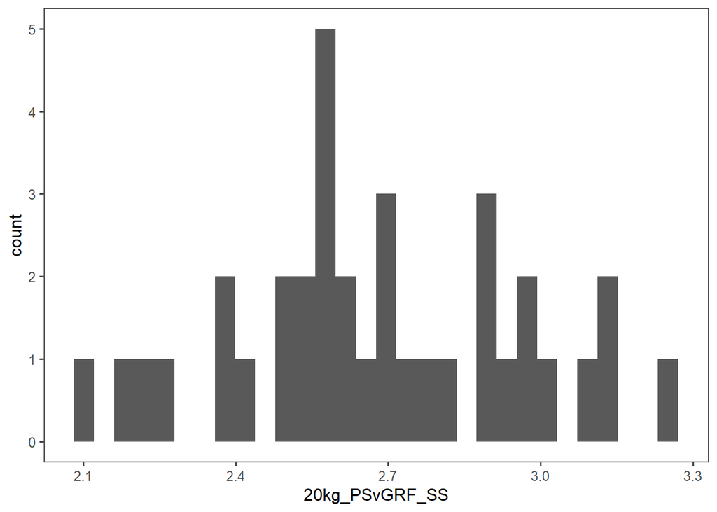

```r
ggplot(dat, aes( x=`20kg_PSvGRF_SS`))+
  geom_histogram()+theme_few()
```

Now let’s change the number of bins from the default. R may have already printed you a warning message telling you to do this when you made the last plot

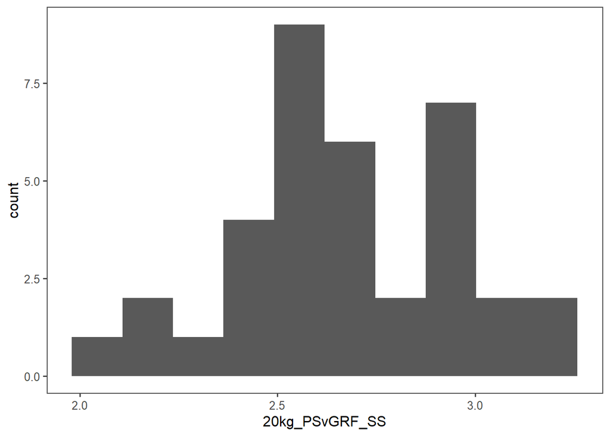

```r
ggplot(dat, aes( x=`20kg_PSvGRF_SS`))+
  geom_histogram(bins=10)+theme_few()
```

What do you think will happen if we try 100 bins?

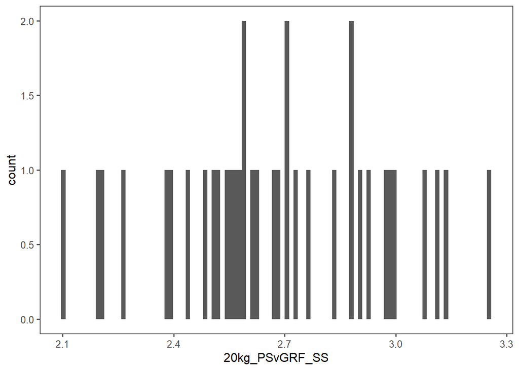

```r
ggplot(dat, aes( x=`20kg_PSvGRF_SS`))+
  geom_histogram(bins=100)+theme_few()
```

We can also customize the color. See what happens when you run the following

```r
#ggplot(dat, aes( x=`20kg_PSvGRF_SS`))+
  #geom_histogram(color=red)+theme_few()
```

That didnt work! Why?

Red needs to be in quotes since we want R to recognize that it’s a word, not a value we have saved in our global environment

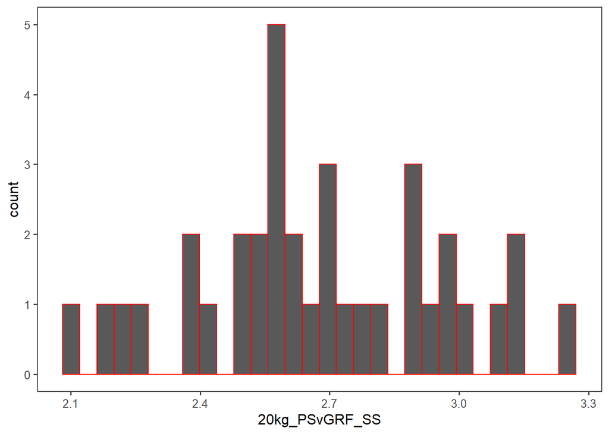

```r
ggplot(dat, aes( x=`20kg_PSvGRF_SS`))+
  geom_histogram(color='red')+theme_few()
```

That looks a bit weird. That’s because the `color()` function only makes the outlines of the plot colored for some plot types.

The function that we were likely looking for is `fill()`.

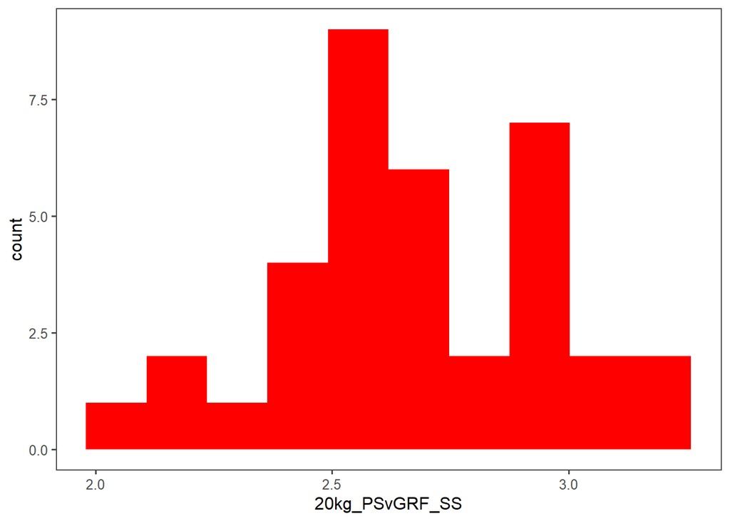

```r
ggplot(dat, aes( x=`20kg_PSvGRF_SS`))+
  geom_histogram(fill='red', bins=10)+theme_few()
```

That’s more like it!

This plot still isn’t the greatest thing in the world though. One obvious thing we should change are the axis labels.

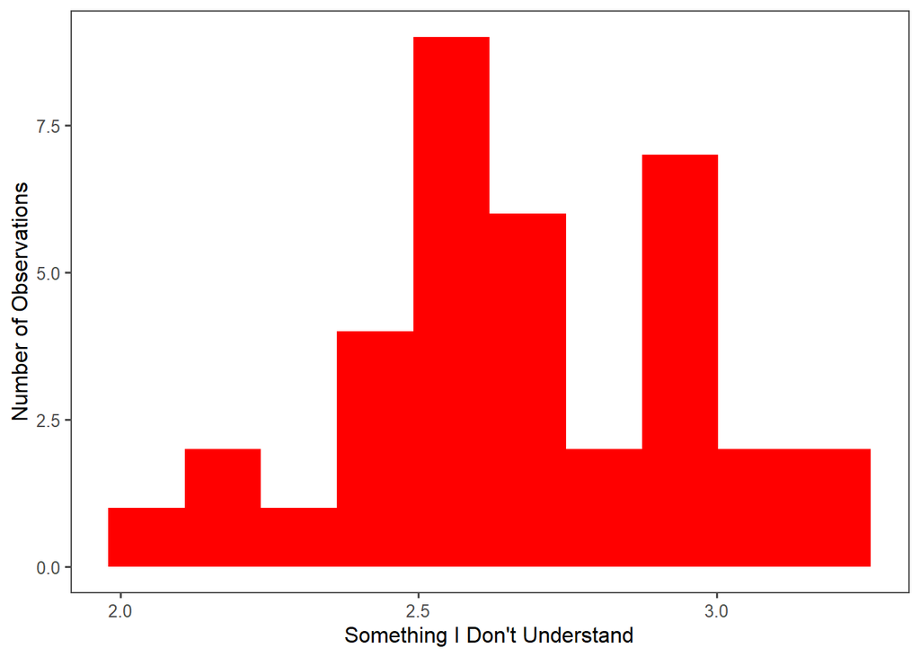

```r
ggplot(dat, aes( x=`20kg_PSvGRF_SS`))+
  geom_histogram(fill='red', bins=10)+theme_few()+
xlab("Something I Don't Understand")+
  ylab("Number of Observations")
```

Now let’s add a title

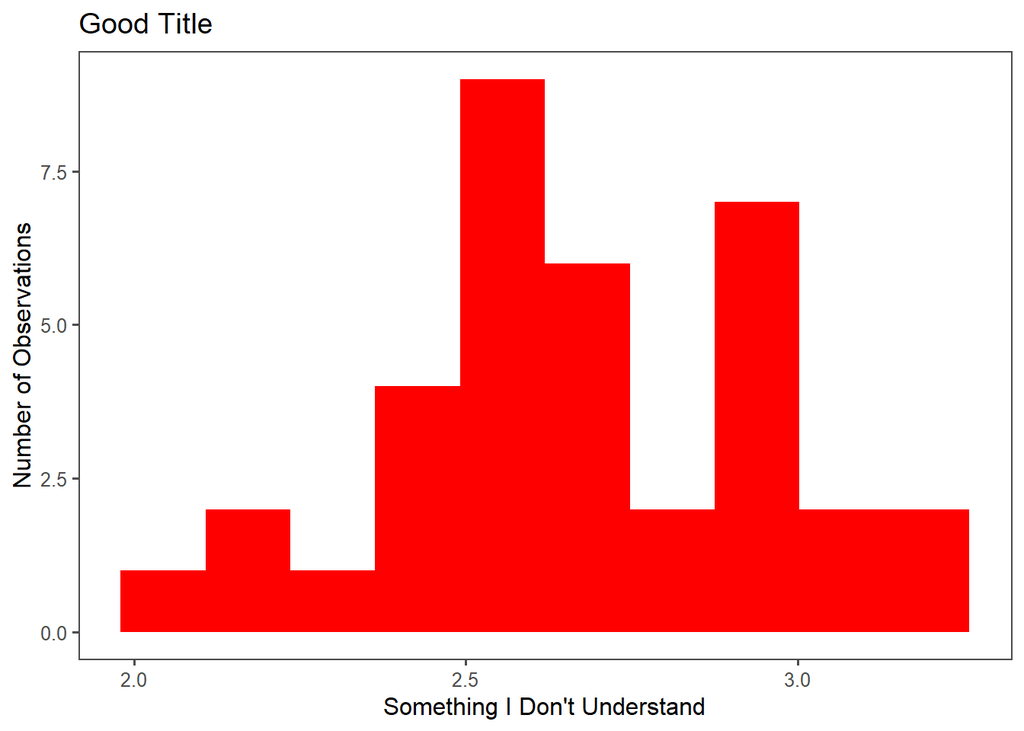

```r
ggplot(dat, aes( x=`20kg_PSvGRF_SS`))+
  geom_histogram(fill='red', bins=10)+theme_few()+
  xlab("Something I Don't Understand")+
  ylab("Number of Observations")+
  ggtitle("Good Title")
```

Fixup our text a bit

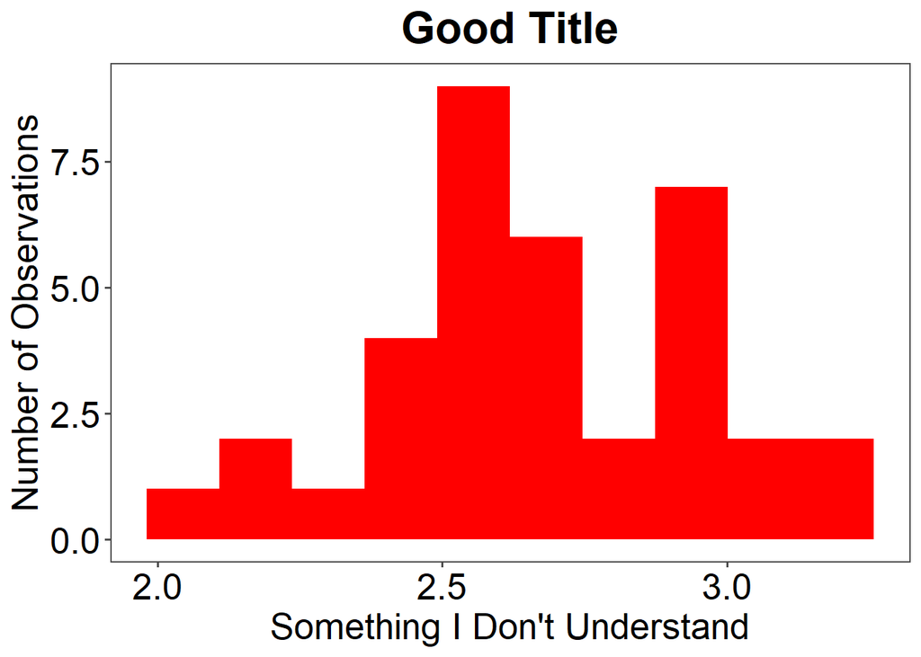

```r
ggplot(dat, aes( x=`20kg_PSvGRF_SS`))+
  geom_histogram(fill='red', bins=10)+theme_few()+
  xlab("Something I Don't Understand")+
  ylab("Number of Observations")+
  ggtitle("Good Title")+
theme(text=element_text(size=20),
      axis.text = element_text(size=20, color="black"),
      plot.title = element_text(lineheight=.8, face="bold",hjust=0.5))
```

Now, the Y axis ticks don’t make sense for count data. We want them to be discrete numbers. Let’s specify where we want the tick marks.

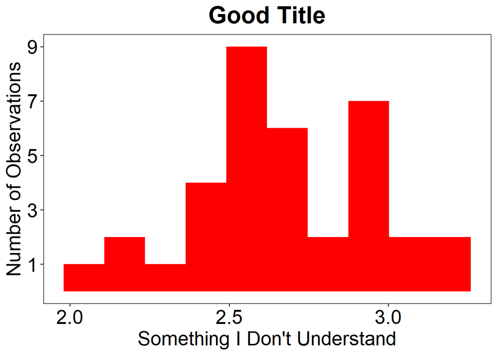

```r
ggplot(dat, aes( x=`20kg_PSvGRF_SS`))+
  geom_histogram(fill='red', bins=10)+theme_few()+
  xlab("Something I Don't Understand")+
  ylab("Number of Observations")+
  ggtitle("Good Title")+
  theme(text=element_text(size=20),
        axis.text = element_text(size=20, color="black"),
        plot.title = element_text(lineheight=.8, face="bold",hjust=0.5))+
  scale_y_continuous(breaks=c(1,3, 5, 7,9))
```

### Examine a continuous variable by a categorical variable

Even though the plots we’re about to make may *look* more complicated, we’ll see that the code that generates them is actually pretty similar to what’s above.

Let’s look at the distribution of the `20kg_PSvGRF_SS` variable, broken up by Sex. A good way to do this is a boxplot.

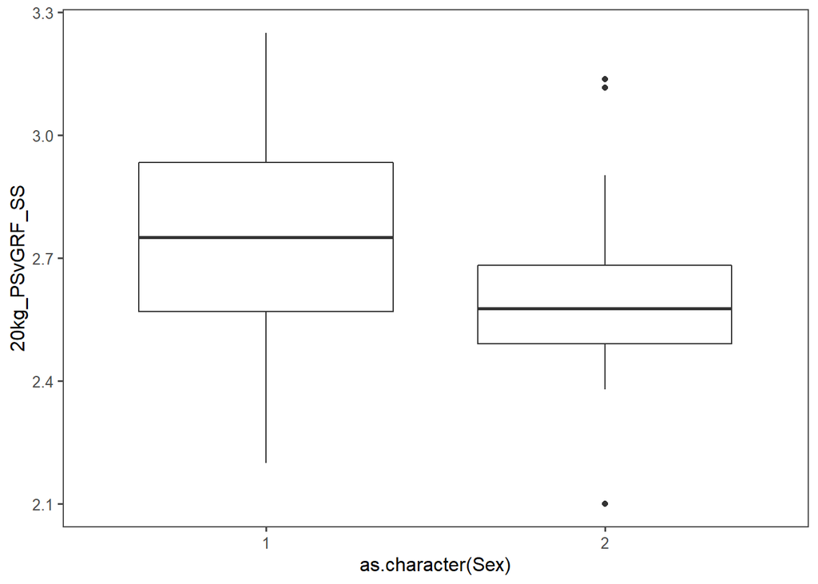

```r
ggplot(dat, aes(x=as.character(Sex), y=`20kg_PSvGRF_SS`))+
  geom_boxplot()+theme_few()
```

What if we want to look at this same variable for each participant. Would it make sense to use a boxplot for this?

No! There’s no distribution of data, only one measurement for each participant.

Let’s use points instead.

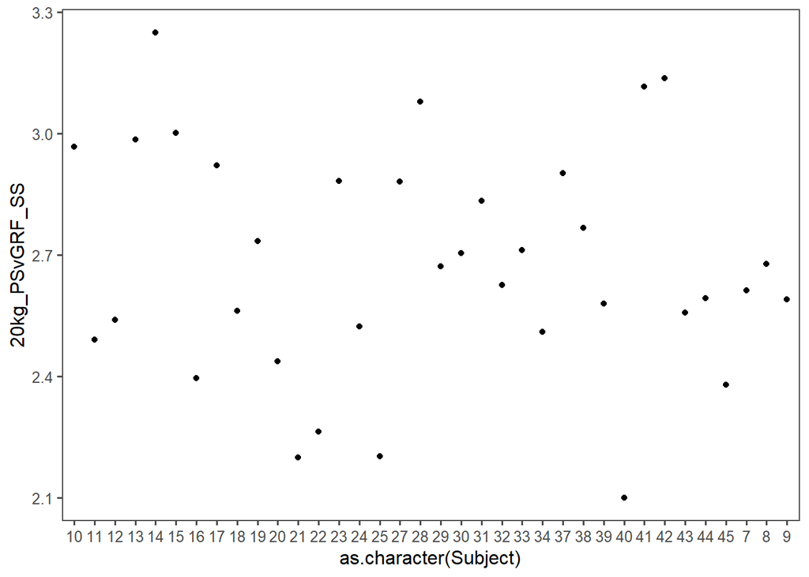

```r
ggplot(dat, aes(x=as.character(Subject), y=`20kg_PSvGRF_SS`))+
  geom_point()+theme_few()
```

We can change the shape of the points pretty easily. Try whatever your favorite number is!

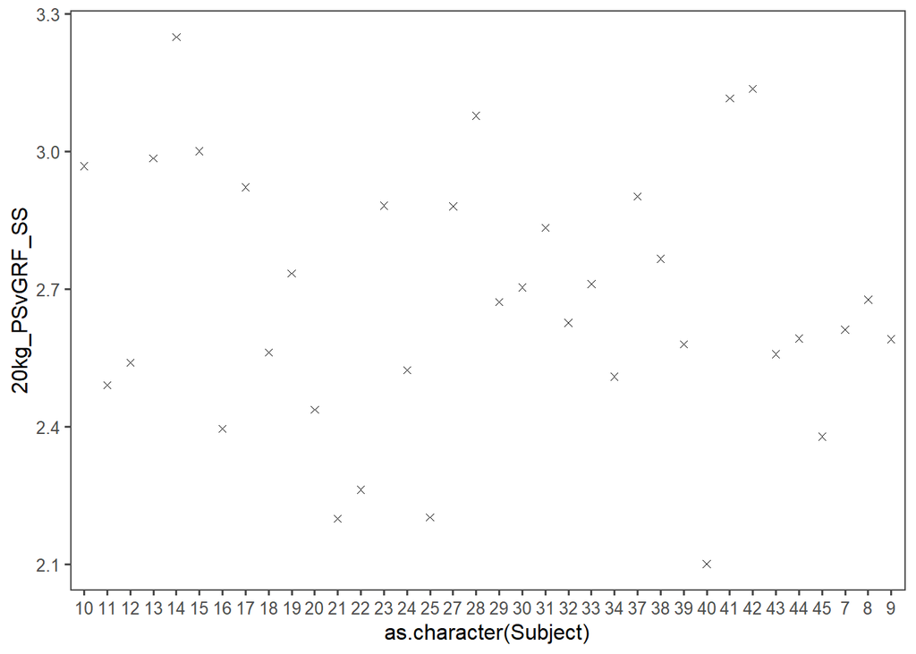

```r
ggplot(dat, aes(x=as.character(Subject), y=`20kg_PSvGRF_SS`))+
  geom_point(shape=4)+theme_few()
```

Another way to look at continuous variables by certain categories is by using density plots.

Notice here that we change the colors by using a HEX code. The colors displayed below are colorblind friendly and b/w print safe. Feel free to steal these!

Lastly, note that now we assign a ‘p’ variable, then make our plot. This is standard syntax that many people use to minimize keystrokes when making multiple plots.

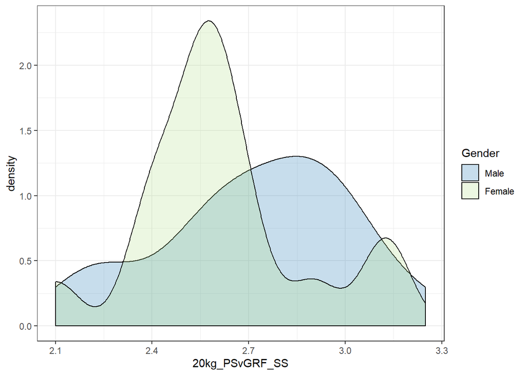

```r
p <- ggplot(dat, aes(`20kg_PSvGRF_SS`))
p + geom_density(aes(fill=as.character(Sex)), alpha=1/4)+
  theme_bw()+ #show color brewer
  scale_fill_manual(values=c("#1f78b4","#b2df8a"),labels=c("Male","Female"),
                     name=("Gender"))
```

### Examine a continuous variable by a continuous variable

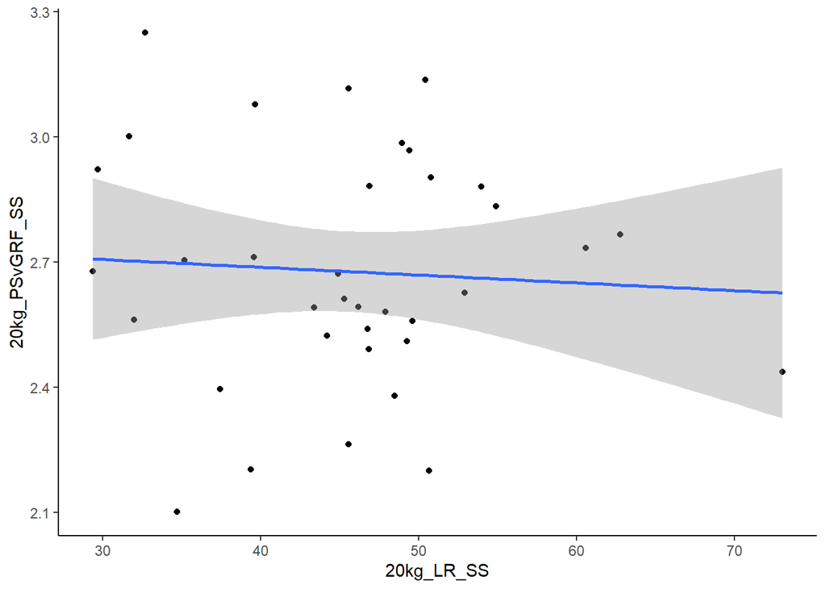

```r
ggplot(dat, aes(x= `20kg_LR_SS`, y=`20kg_PSvGRF_SS`))+
  geom_point()+
  geom_smooth(method= "lm")+
  theme_classic()
```

See if you can make the dots bigger on your own!

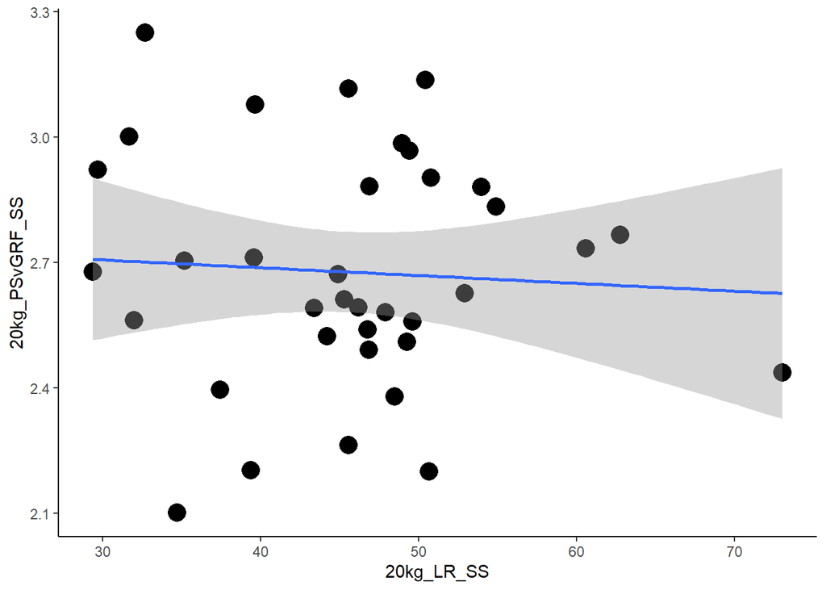

```r
ggplot(dat, aes(x= `20kg_LR_SS`, y=`20kg_PSvGRF_SS`))+
  geom_point(size=5)+
  geom_smooth(method= "lm")+
  theme_classic()
```

That was easy, now try to color the points by sex.

```r
#ggplot(dat, aes(x= `20kg_LR_SS`, y=`20kg_PSvGRF_SS`))+
 # geom_point(aes(color=Sex))+
  #geom_smooth(method= "lm")+
  #theme_classic()
```

Well that didnt work. Why not?

Our `Sex` variable is saved as an integer. We need R to recognize that `Sex` is a category!

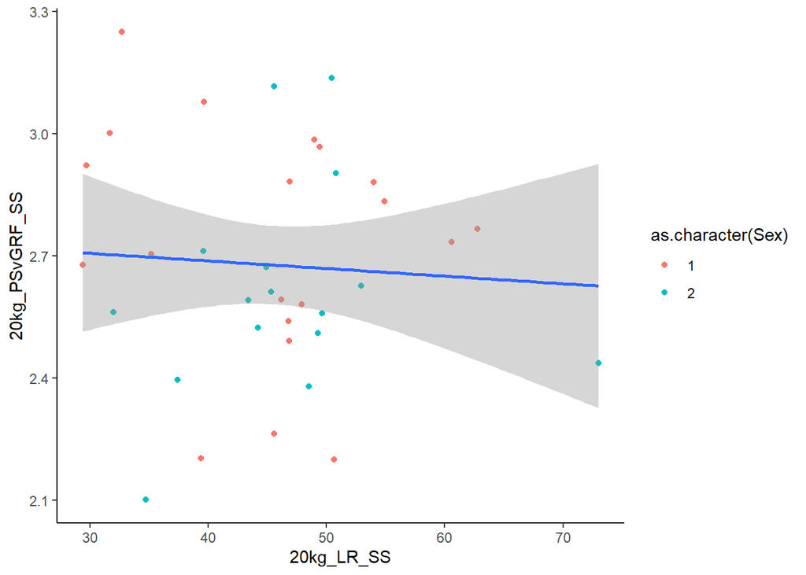

```r
ggplot(dat, aes(x= `20kg_LR_SS`, y=`20kg_PSvGRF_SS`))+
  geom_point(aes(color=as.character(Sex)))+
  geom_smooth(method= "lm")+
  theme_classic()
```

Let’s make the trendlines by gender too

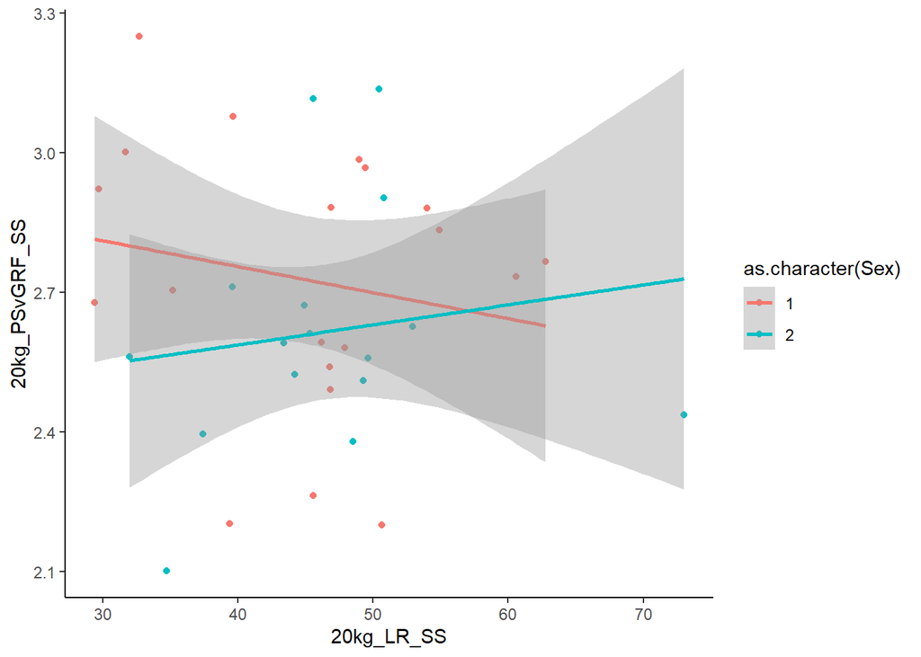

```r
ggplot(dat, aes(x= `20kg_LR_SS`, y=`20kg_PSvGRF_SS`))+
  geom_point(aes(color=as.character(Sex)))+
  geom_smooth(aes(color=as.character(Sex)),method= "lm")+
  theme_classic()
```

Our legend needs some love. Let’s also change out of this terrible stock color scheme.

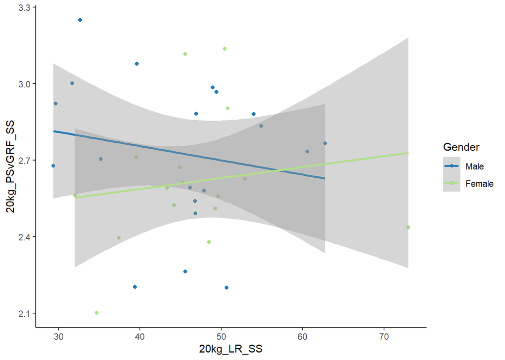

```r
ggplot(dat, aes(x= `20kg_LR_SS`, y=`20kg_PSvGRF_SS`))+
  geom_point(aes(color=as.character(Sex)))+
  geom_smooth(aes(color=as.character(Sex)),method= "lm")+
  theme_classic()+ #show color brewer
scale_color_manual(values=c("#1f78b4","#b2df8a"),labels=c("Male","Female"),
                              name=("Gender"))
```

## Facet our plots by a categorical variable

Let’s make a dummy `Treatment’ variable that we will use for our facets.

We’re going to imagine that each of our 36 participants got either `Treatment` A, B, C, or D.

```r
dat$Treatment<-c(rep("A",9), rep("B",9),rep("C",9),rep("D",9))
```

Make sure that worked. It should be the final column in the data now.

```r
names(dat)
```

```
##   [1] "Subject"               "Sex"
##   [3] "20kg_PSvGRF_SS"        "20kg_LR_SS"
##   [5] "20kg_ImpactPeak_SS"    "20kg_LegStiff_SS"
##   [7] "20kg_ChangeLL_SS"      "20kg_ICLL_SS"
##   [9] "20kg_MinLL_SS"         "20kg_HipStiff_SS"
##  [11] "20kg_PSHipFlxAng_SS"   "20kg_PSHipFlxMom_SS"
##  [13] "20kg_KneeStiff_SS"     "20kg_PSKneeFlxAng_SS"
##  [15] "20kg_PSKneeFlxMom_SS"  "20kg_AnkleStiff_SS"
##  [17] "20kg_PSAnkleFlxAng_SS" "20kg_PSAnkleFlxMom_SS"
##  [19] "20kg_PSvGRF_PS"        "20kg_LR_PS"
##  [21] "20kg_ImpactPeak_PS"    "20kg_LegStiff_PS"
##  [23] "20kg_ChangeLL_PS"      "20kg_ICLL_PS"
##  [25] "20kg_MinLL_PS"         "20kg_HipStiff_PS"
##  [27] "20kg_PSHipFlxAng_PS"   "20kg_PSHipFlxMom_PS"
##  [29] "20kg_KneeStiff_PS"     "20kg_PSKneeFlxAng_PS"
```

[output cut: 83 more lines]

Now that that’s done, let’s get faceting!

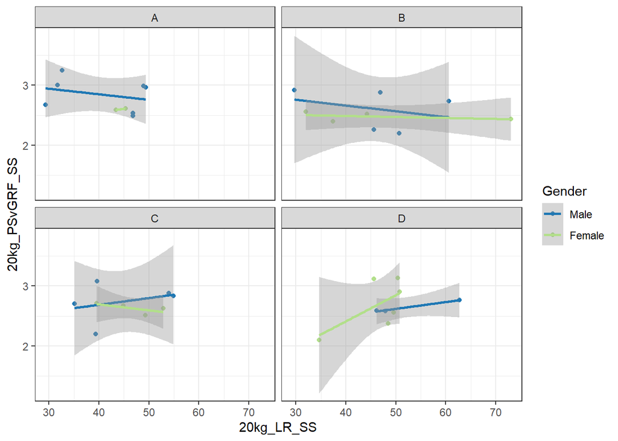

```r
ggplot(dat, aes(x= `20kg_LR_SS`, y=`20kg_PSvGRF_SS`))+
  geom_point(aes(color=as.character(Sex)))+
  geom_smooth(aes(color=as.character(Sex)),method= "lm")+
  facet_wrap( ~ Treatment, ncol=2)+
  theme_bw()+ #show color brewer
  scale_color_manual(values=c("#1f78b4","#b2df8a"),labels=c("Male","Female"),
                     name=("Gender"))
```

We can do the same thing with the density pllts we made before

Notice that the X variable is changed here. This one just looked better than the other one.

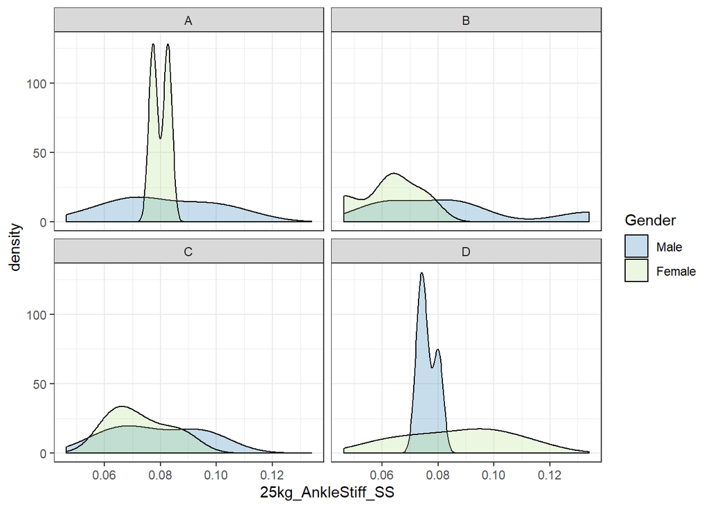

```r
p <- ggplot(dat, aes(`25kg_AnkleStiff_SS`))
p + geom_density(aes(fill=as.character(Sex)), alpha=1/4)+
  facet_wrap( ~ Treatment, ncol=2)+
  theme_bw()+ #show color brewer
  scale_fill_manual(values=c("#1f78b4","#b2df8a"),labels=c("Male","Female"),
                    name=("Gender"))
```

**Activity:**_ Make any plot, show your partner, have them write the code that think was used to make it